# final_R_reference

Heather Siart

12/2/2021

# R Reference Guide

## Loading Data and Packages

```r
require("here")
require(palmerpenguins)
delomys = read.csv(here("data", "delomys.csv"))
ginkgo = read.csv(here("data", "ginkgo_data_2021.csv"))
```

## Data Structures

### C()

The function c() combines or concatenates its arguments into a vector (a 1-dimensional data structure consisting of 1 or more elements).

- All of the elements must be of the same type.
- I can’t combine character and numeric types in the same call to c()

Here’s two examples using numeric and character data types:

```r
## Create a vector of numbers:
num_vec  = c(1, 4, 8, 9, 13)

## Create a vector of characters:
char_vec = c("a", "fish", "data is cool")
```

I can show the contents of a vector by typing the name of the vector, or using the print() function.

```r
## Typing the name of the vector into the console prints the contents
num_vec
```

```
## [1]  1  4  8  9 13
```

```r
## The print() function accomplishes the same task:
print(char_vec)
```

```
## [1] "a"            "fish"         "data is cool"
```

### length()

You can use length() to get or set the length of vectors and factors, and other R objects where a method has been defined.

```r
length(ginkgo$max_width)
```

```
## [1] 756
```

### matrix()

Makes a matrix from a given set of values

```r
mat = matrix(1:28, nrow = 4, ncol = 4)
print(mat)
```

```
##      [,1] [,2] [,3] [,4]
## [1,]    1    5    9   13
## [2,]    2    6   10   14
## [3,]    3    7   11   15
## [4,]    4    8   12   16
```

### data.frame()

Tightly coupled collections of variables which share many of the properties of matrices an of lists, used as the fundamental data structure by most of R’s modeling software

```r
cat = data.frame(1:10)
print(cat)
```

```
##    X1.10
## 1      1
## 2      2
## 3      3
## 4      4
## 5      5
## 6      6
## 7      7
## 8      8
## 9      9
## 10    10
```

### nrow()

returns the number of rows in a vector, array, or data frame

nrow(x)

x = a vector, array, data frame, or NULL

```r
nrow(mat)
```

```
## [1] 4
```

### ncol()

returns the number of columns in a vector, array, or data frame

xcol(x)

x = a vector, array, data frame, or NULL

```r
ncol(mat)
```

```
## [1] 4
```

```r
dat = matrix(1:49, nrow = 7, ncol = 7)
print(dat)
```

```
##      [,1] [,2] [,3] [,4] [,5] [,6] [,7]
## [1,]    1    8   15   22   29   36   43
## [2,]    2    9   16   23   30   37   44
## [3,]    3   10   17   24   31   38   45
## [4,]    4   11   18   25   32   39   46
## [5,]    5   12   19   26   33   40   47
## [6,]    6   13   20   27   34   41   48
## [7,]    7   14   21   28   35   42   49
```

### dim()

Dimensions of an object

dim(x)

dim(x) <- value

x = an R object, for example a matrix, array or data frame

value = for a default nethod, either NULL or a numeric vector, which is coerced to integers (by truncation)

```r
dim(dat)
```

```
## [1] 7 7
```

## Subsetting

### $

Subset a data frame by name: select one of the columns in the ginkgo data

```r
Gnotch = (ginkgo$notch_depth)
```

### []

Use subset by position to:

- select first row of the ginkgo data
- select the element in row 2, column 3
- select the 3rd column of the ginkgo data

```r
# First row of the ginkgo data
ginkgo[1, ]
```

```
##   ï..site_id seeds_present max_width max_depth notch_depth petiole_length
## 1       7719         FALSE        71        40           0             30
```

```r
# Element in row 2, column 3
ginkgo[2, 3]
```

```
## [1] 64
```

```r
# 3rd column of the ginkgo data
ginkgo[ ,3]
```

```
##   [1]  71.0  64.0  55.0  62.0  65.0  70.0  63.0  56.0  51.0  57.0  59.0  63.0
##  [13]  70.0  50.0  56.0  46.0  54.0  62.0  56.0  55.0  59.0  60.0  63.0  61.0
##  [25]  58.0  55.0  53.0  81.0  94.0  75.0  82.0  86.0  79.0  93.0  88.0  76.0
##  [37]  71.0  91.0  71.0  82.0  65.0  83.0  73.0 102.0  78.0  88.0  81.0  70.0
##  [49]  80.0  96.0  80.0  82.0  86.0  87.0  89.0  69.0  93.0  98.0  81.0  79.0
##  [61]  82.0  85.0  81.0  59.0  53.0  83.0  80.0  77.0  81.0  76.0  82.0  81.0
##  [73]  77.0  68.0  41.0  70.0  68.0  80.0  89.0  90.0  71.0  64.0  55.0  62.0
##  [85]  65.0  70.0  63.0  56.0  51.0  57.0  59.0  63.0  70.0  50.0  56.0  46.0
##  [97]  54.0  62.0  56.0  55.0  59.0  60.0  63.0  61.0  58.0  55.0  53.0  77.0
## [109]  72.0  57.0  75.0  75.0  75.0  67.0  74.0  71.0  72.0  55.0  77.0  97.0
## [121]  73.0  64.0  69.0  92.0  64.0  68.0  53.0  97.0 100.0  90.0  89.0  59.0
## [133]  97.0  76.0  85.0  90.0  87.0  85.0  80.0  86.0  89.0  84.0  88.0  80.0
## [145] 102.0  94.0  95.0 109.0  84.0  68.0  59.0  74.0  70.0  71.0  69.0  74.0
## [157]  70.0  78.0  87.0  69.0  60.0  72.0  59.0  75.0  81.0  82.0  74.0  72.0
## [169]  79.0  84.0  75.0  72.0  88.0  80.0  90.0  58.0  61.0  95.0  72.0  90.0
```

[output cut: 48 more lines]

### subset()

Use this function to retrieve all the data for Adelie penguins (in the species column) from the peuguins dataset.

```r
All_Adelie = subset(penguins, species=="Adelie")
```

## Numerical Data Exploration

### summary()

summary = used to show results of various model fitting functions or objects

```r
summary(num_vec)
```

```
##    Min. 1st Qu.  Median    Mean 3rd Qu.    Max.
##       1       4       8       7       9      13
```

### mean()

mean = the average of the data

mean(x, …)

x = an R object

```r
mean(ginkgo$max_width)
```

```
## [1] 74.33823
```

### sd()

sd or standard deviation,

sd(x, na.rm = FALSE)

x = a numeric vector or an R object but not a factor coercible to numeric by as.double(x)

na.rm = logical. Should missing values be removed? (if FALSE, you don’t need to add it into the code)

```r
sd(ginkgo$max_width, na.rm = FALSE)
```

```
## [1] 16.4203
```

```r
sd(ginkgo$max_width, na.rm = TRUE)
```

```
## [1] 16.4203
```

## Graphical Data Exploration

### Scatterplot:

Using the ginkgo data, create a scatterplot of max leaf depth (x) and max leaf width (y).

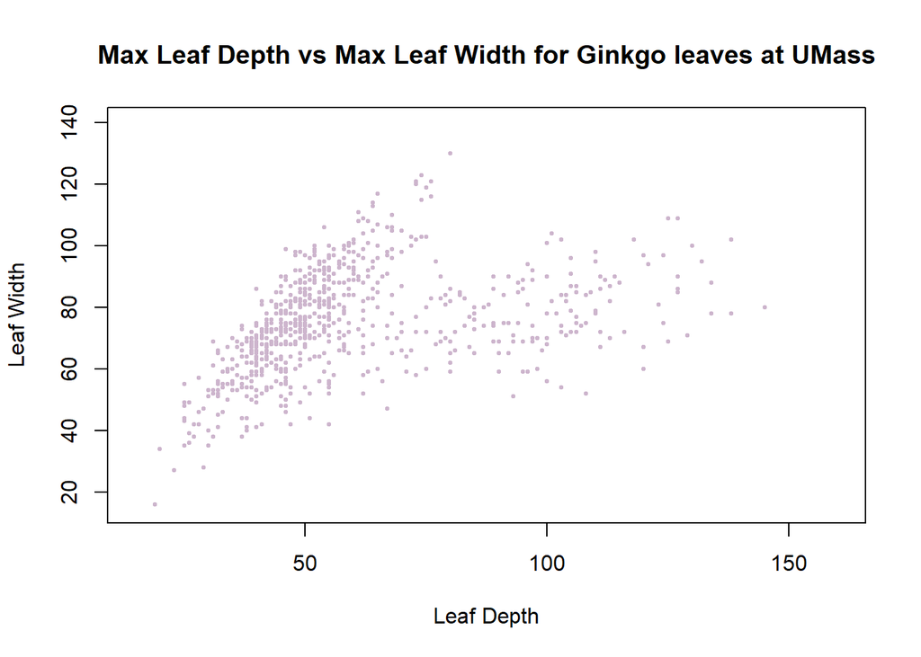

```r
plot(ginkgo$max_depth, ginkgo$max_width,
     main = "Max Leaf Depth vs Max Leaf Width for Ginkgo leaves at UMass",
     xlab = "Leaf Depth",
     ylab = "Leaf Width",
     col = "thistle3",
     pch = 20,
     cex = 0.60,
     xlim = c(15, 160),
     ylim = c(15, 140)
     )
```

### plot() required arguments:

- col = Changes the color of the plotted data
- pch = defines the point symbols in the plot
- cex = Changes the size of the data points on the graph
- main = Title of the graph
- xlab = Label the x axis
- ylab = Label the y axis
- xlim = Sets the range limit of the x axis
- ylim = Sets the range limit of the y axis

### hist()

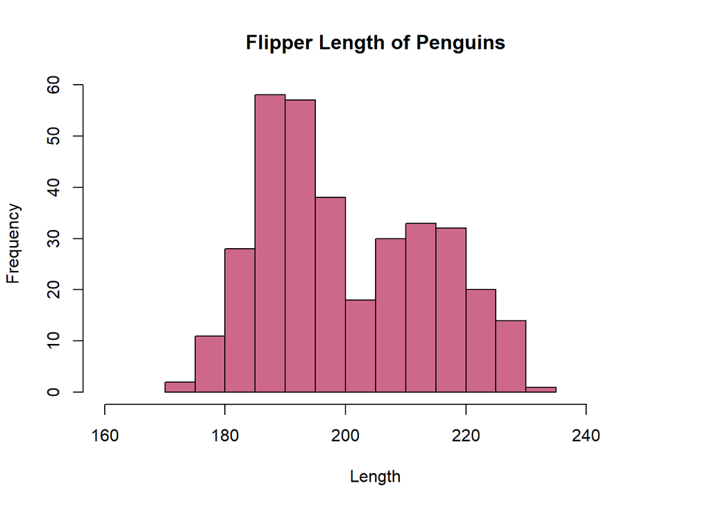

```r
hist(penguins$flipper_length_mm,
     main = "Flipper Length of Penguins",
     xlab = "Length", col = "palevioletred3",
     xlim = c(160, 250), breaks = 10)
```

### boxplot()

You must include two examples using the ginkgo data:

- 1. a simple boxplot of ginkgo petiole lengths

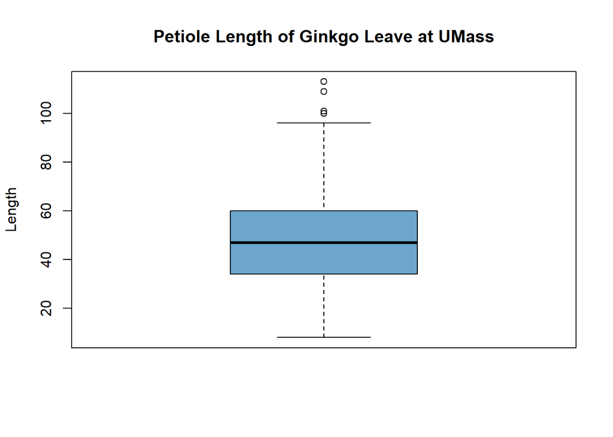

```r
boxplot(ginkgo$petiole_length,
        main = "Petiole Length of Ginkgo Leave at UMass",
        xlab = "",
        ylab = "Length",
        col = "skyblue3")
```

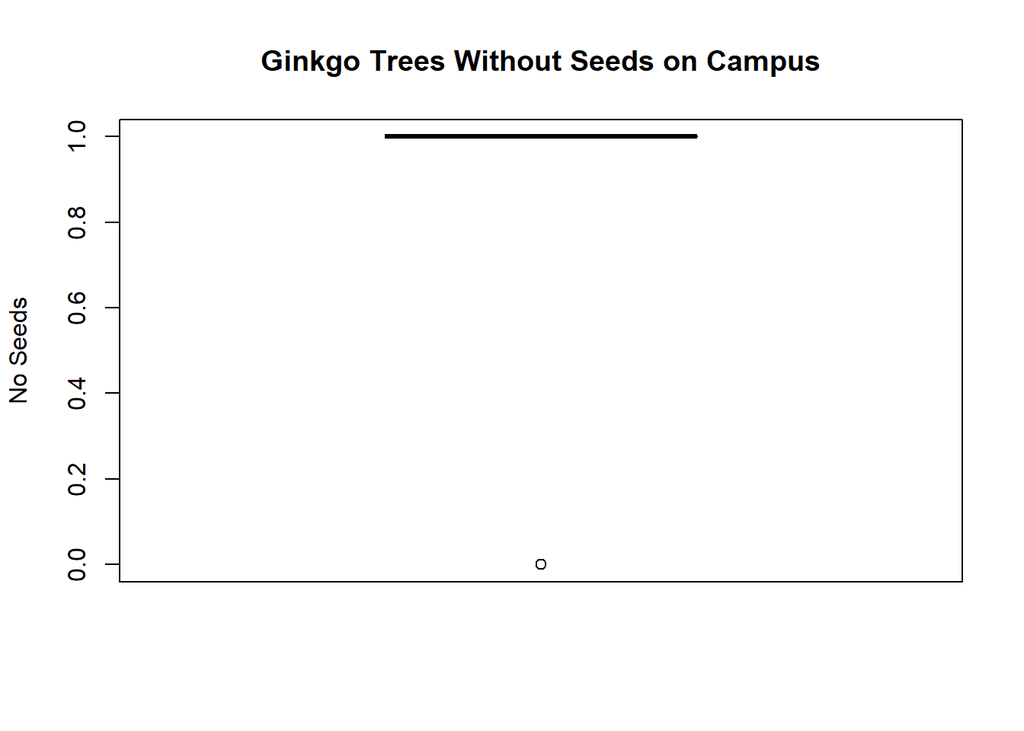

```r
boxplot(ginkgo$seeds_present == FALSE,
        main = "Ginkgo Trees Without Seeds on Campus",
        ylab = "No Seeds",
        col = "azure4")
```

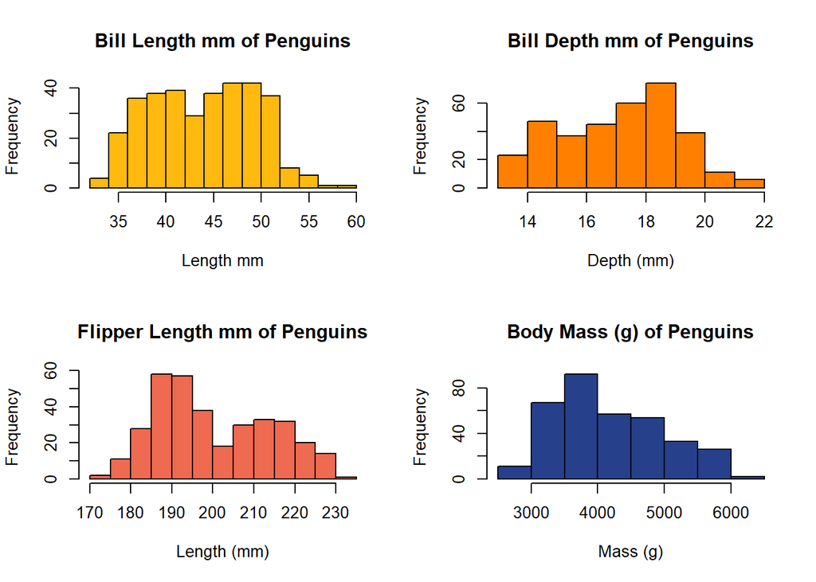

```r
par(mfrow = c(2, 2))
hist(penguins$bill_length_mm,
     main = "Bill Length mm of Penguins",
        xlab = "Length mm",
        ylab = "Frequency",
        col = "darkgoldenrod1")

hist(penguins$bill_depth_mm,
     main = "Bill Depth mm of Penguins",
        xlab = "Depth (mm)",
        ylab = "Frequency",
        col = "darkorange1")

hist(penguins$flipper_length_mm,
     main = "Flipper Length mm of Penguins",
        xlab = "Length (mm)",
        ylab = "Frequency",
        col = "coral2")

hist(penguins$body_mass_g,
     main = "Body Mass (g) of Penguins",
        xlab = "Mass (g)",
        ylab = "Frequency",
        col = "royalblue4")
```

## Distribution Functions

### dnorm()

dnorm or the normal distribution

dnorm(x, mean = 0, sd = 1, log = FALSE)

x = vector quantiles mean = vector of means sd = vector of standard deviations log = logical; if TRUE probablilities p are given as log(p)

### pnorm()

pnorm or the normal distribution

pnorm(q, mean = 0, sd = 1, lower.tail = TRUE, log.p = FALSE)

q = vector quantiles mean = vector of means sd = vector of standard deviations lower.tail = logical; if TRUE (default), probabilities are P[X <= x] otherwise, P[X >x] log.p = logical; if TRUE probablilities p are given as log(p)

### qnorm()

qnorm or the normal distribution

qnorm(p, mean = 0, sd = 1, lower.tail = TRUE, log.p = FALSE )

p = vector of probabilities mean = vector of means sd = vector of standard deviations lower.tail = logical; if TRUE (default), probabilities are P[X <= x] otherwise, P[X >x] log = logical; if TRUE probablilities p are given as log(p)

### dbinom()

dbinom or the binomial distribution

dbinom(x, size, prob, log = FALSE)

x = vector of quantiles

### pbinom()

pbinom or the binomial distribution

pbinom(q, size, prob, lower.tail = TRUE, log.p = FALSE)

q = vector of quantiles

### qbinom()

qbinom or the binomial distribution

qbinom(p, size, prob, lower.tail = TRUE, log.p = FALSE)

p = vector of probabilities